# DATA 621: WEEK 1 ASSIGNMENT

MUSA T. GANIYU

June 8, 2016

```r
options(warn = -1)

suppressMessages(require(plotly))
library(knitr)
suppressMessages(library(RCurl))
suppressMessages(library(plyr))
suppressMessages(library(ggplot2))
suppressMessages(library(plotly))
suppressMessages(require(scatterplot3d));



training <- read.csv("https://raw.githubusercontent.com/honeyberk/data621/master/final_train.csv", header = TRUE, sep = ",")

evaluation <- read.csv("https://raw.githubusercontent.com/mascotinme/MSDA-IS621/master/moneyball-training-data.csv", header = TRUE, sep = ",")

str(training)
```

```
## 'data.frame':    2276 obs. of  15 variables:
##  $ wins            : int  39 70 86 70 82 75 80 85 86 76 ...
##  $ base_hits       : int  1445 1339 1377 1387 1297 1279 1244 1273 1391 1271 ...
##  $ singles         : int  1199 908 973 1044 982 951 889 950 1040 944 ...
##  $ doubles         : int  194 219 232 209 186 200 179 171 197 213 ...
##  $ triples         : int  39 22 35 38 27 36 54 37 40 18 ...
##  $ homeruns        : int  13 190 137 96 102 92 122 115 114 96 ...
##  $ walks           : int  143 685 602 451 472 443 525 456 447 441 ...
##  $ b_strikeouts    : int  842 1075 917 922 920 973 1062 1027 922 827 ...
##  $ stolen_bases    : int  307 37 46 43 49 107 80 40 69 72 ...
##  $ hits_allowed    : int  2009 1347 1377 1396 1297 1279 1244 1281 1391 1271 ...
##  $ homeruns_allowed: int  84 191 137 97 102 92 122 116 114 96 ...
##  $ walks_allowed   : int  454 689 602 454 472 443 525 459 447 441 ...
##  $ p_strikeouts    : int  1385 1082 917 928 920 973 1062 1033 922 827 ...
##  $ errors          : int  248 193 175 164 138 123 136 112 127 131 ...
##  $ double_plays    : int  162 155 153 156 168 149 186 136 169 159 ...
```

```r
dim(training)
```

```
## [1] 2276   15
```

```r
kable(summary(training))
```

|  | wins | base_hits | singles | doubles | triples | homeruns | walks | b_strikeouts | stolen_bases | hits_allowed | homeruns_allowed | walks_allowed | p_strikeouts | errors | double_plays |
| --- | --- | --- | --- | --- | --- | --- | --- | --- | --- | --- | --- | --- | --- | --- | --- |
|  | Min. : 0.00 | Min. :1156 | Min. : 811 | Min. : 69.0 | Min. : 0.00 | Min. : 0.00 | Min. : 0.0 | Min. : 0.0 | Min. : 0.00 | Min. :1137 | Min. : 0.0 | Min. :277.0 | Min. : 181.0 | Min. : 65.0 | Min. : 52.0 |
|  | 1st Qu.: 71.00 | 1st Qu.:1383 | 1st Qu.: 990 | 1st Qu.:208.0 | 1st Qu.: 34.00 | 1st Qu.: 42.00 | 1st Qu.:451.0 | 1st Qu.: 545.8 | 1st Qu.: 66.75 | 1st Qu.:1419 | 1st Qu.: 50.0 | 1st Qu.:475.0 | 1st Qu.: 608.0 | 1st Qu.:127.0 | 1st Qu.:124.0 |
|  | Median : 82.00 | Median :1453 | Median :1050 | Median :238.0 | Median : 47.00 | Median :102.00 | Median :512.0 | Median : 735.0 | Median :105.00 | Median :1518 | Median :107.0 | Median :536.0 | Median : 800.0 | Median :158.0 | Median :145.0 |
|  | Mean : 80.79 | Mean :1462 | Mean :1065 | Mean :241.2 | Mean : 55.25 | Mean : 99.61 | Mean :501.6 | Mean : 729.0 | Mean :122.48 | Mean :1578 | Mean :105.7 | Mean :544.7 | Mean : 792.4 | Mean :191.0 | Mean :141.1 |
|  | 3rd Qu.: 92.00 | 3rd Qu.:1535 | 3rd Qu.:1127 | 3rd Qu.:273.0 | 3rd Qu.: 72.00 | 3rd Qu.:147.00 | 3rd Qu.:580.0 | 3rd Qu.: 925.0 | 3rd Qu.:164.00 | 3rd Qu.:1681 | 3rd Qu.:150.0 | 3rd Qu.:610.0 | 3rd Qu.: 957.0 | 3rd Qu.:239.2 | 3rd Qu.:162.0 |
|  | Max. :146.00 | Max. :1768 | Max. :1336 | Max. :458.0 | Max. :223.00 | Max. :264.00 | Max. :878.0 | Max. :1399.0 | Max. :321.00 | Max. :2079 | Max. :343.0 | Max. :810.0 | Max. :1481.0 | Max. :432.0 | Max. :228.0 |

> The Multiple Linear Regression Equation for the data analysis is:

${ Y }\quad =\quad { B }_{ 0 }\quad +\quad { B }_{ 1 }{ x }_{ 1 }\quad +\quad { B }_{ 2 }{ x }_{ 2 }\quad +\quad$ ………+$\quad { B }_{ n }{ x }_{ n }\quad$ +$\quad { e}\\$

Where,

$\quad { Y }\quad$ = Reponse or Dependent Variable,

$\quad{ x }_{ 1 }$ …..${ x }_{ n }\quad$ = Explantory or Independent Variables

$\quad { B }_{ 0 }\quad$ = Intercept,

$\quad { B }_{ 1 }\quad , ...., \quad { B }_{ n }\quad$ = Slope of Independent variables or Model Parameter.

$\quad { e}\\$ = Residual or Error term ( the difference between an actual and a predicted value of y)

**Could be re-written in terms of the training dataset as:**

${ Y }\quad =\quad { B }_{ 0 }\quad +\quad { B }_{ wins }{ X }_{wins}\quad +\quad { B }_{ homeruns}{ X }_{ base_hits }\quad +\quad$ ………+$\quad { B }_{ double_plays }{ X }_{ double_plays }\quad$ +$\quad { e}\\$

> A glimpse at the multiple linear regression Analysis:

```r
fit1 <- lm(wins ~. , data = training) # The Variable index is intentional omitted as it has nothing to do with the analysis

summary(fit1)
```

```
##
## Call:
## lm(formula = wins ~ ., data = training)
##
## Residuals:
##     Min      1Q  Median      3Q     Max
## -53.986  -7.912  -0.080   7.667  63.706
##
## Coefficients:
##                   Estimate Std. Error t value Pr(>|t|)
## (Intercept)      66.914896   5.679832  11.781  < 2e-16 ***
## base_hits         0.013951   0.031019   0.450 0.652932
## singles           0.012200   0.031905   0.382 0.702218
## doubles          -0.007096   0.031574  -0.225 0.822196
## triples           0.175952   0.033857   5.197 2.21e-07 ***
## homeruns          0.075520   0.048420   1.560 0.118978
## walks             0.036420   0.010400   3.502 0.000471 ***
## b_strikeouts     -0.011820   0.006157  -1.920 0.055027 .
## stolen_bases      0.077520   0.005330  14.544  < 2e-16 ***
## hits_allowed      0.006030   0.003784   1.594 0.111178
## homeruns_allowed  0.007833   0.027148   0.289 0.772983
## walks_allowed    -0.014986   0.010158  -1.475 0.140294
## p_strikeouts     -0.010207   0.005425  -1.881 0.060051 .
## errors           -0.137049   0.006426 -21.329  < 2e-16 ***
## double_plays     -0.156633   0.012519 -12.512  < 2e-16 ***
## ---
## Signif. codes:  0 '***' 0.001 '**' 0.01 '*' 0.05 '.' 0.1 ' ' 1
##
## Residual standard error: 12.22 on 2261 degrees of freedom
## Multiple R-squared:  0.4014, Adjusted R-squared:  0.3977
## F-statistic: 108.3 on 14 and 2261 DF,  p-value: < 2.2e-16
```

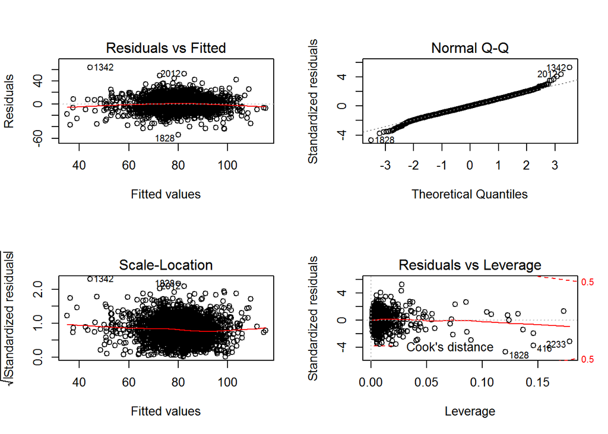

```r
par(mfrow=c(2,2))
plot(fit1)
```

- A scatter Plot and Correlation co-efficient between wins and doubles

```r
plot_ly(data = training, x = doubles , y = wins, mode = "markers",
        color = "blue", line = list(shape = "linear"))
```

[interactive chart not shown]

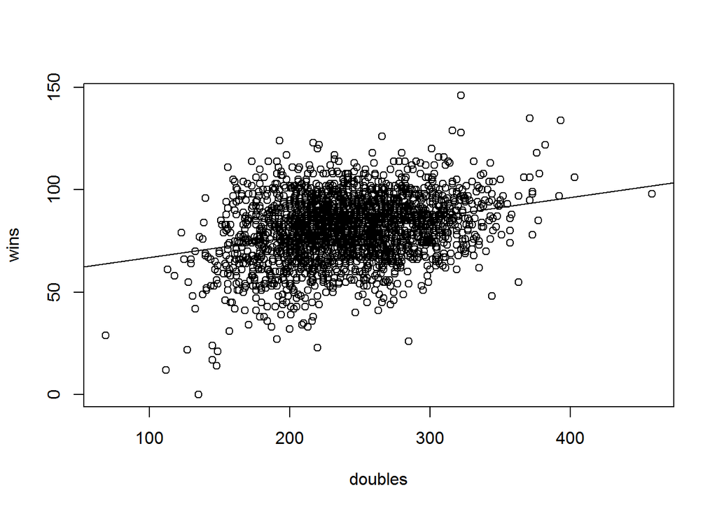

```r
plot(wins~doubles, training)

fitline <- lm(training$wins~training$doubles)
abline(fitline)
```

```r
cor(training$wins, training$doubles)
```

```
## [1] 0.2891036
```

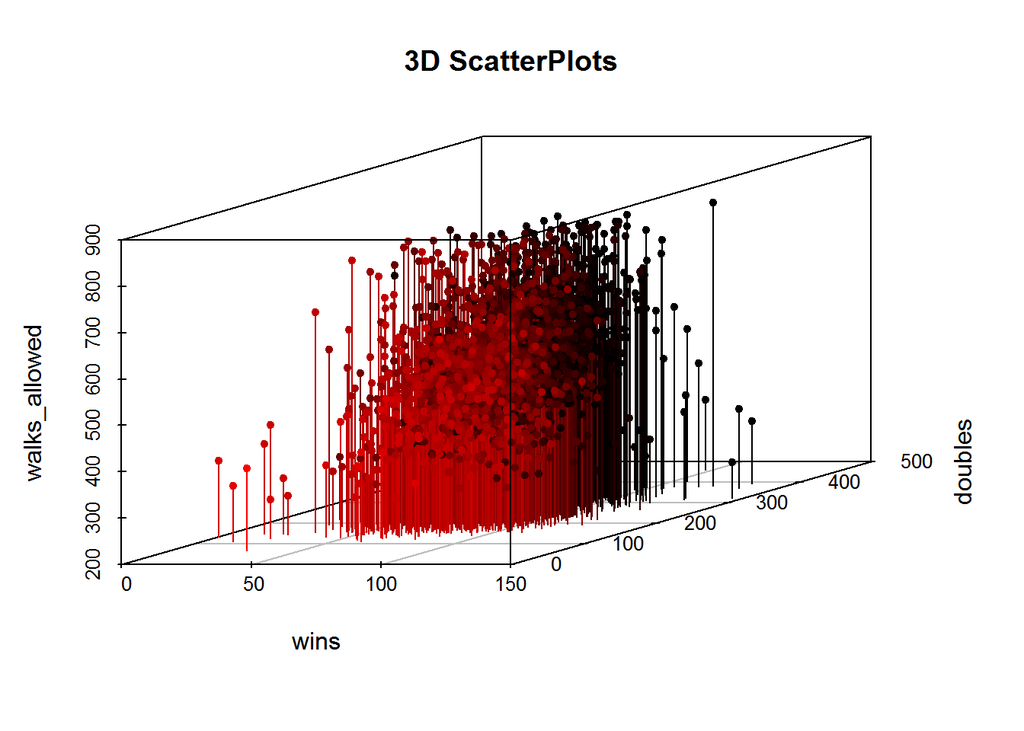

```r
attach(training);

#Run the this query to display it in 3D

scatterplot3d(wins, doubles, walks_allowed ,pch = 20, highlight.3d = TRUE, type = "h", main = "3D ScatterPlots");
```

- A check for Normality.

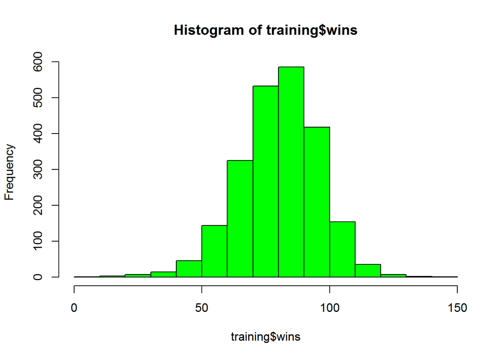

```r
hist(training$wins, col="green")
```

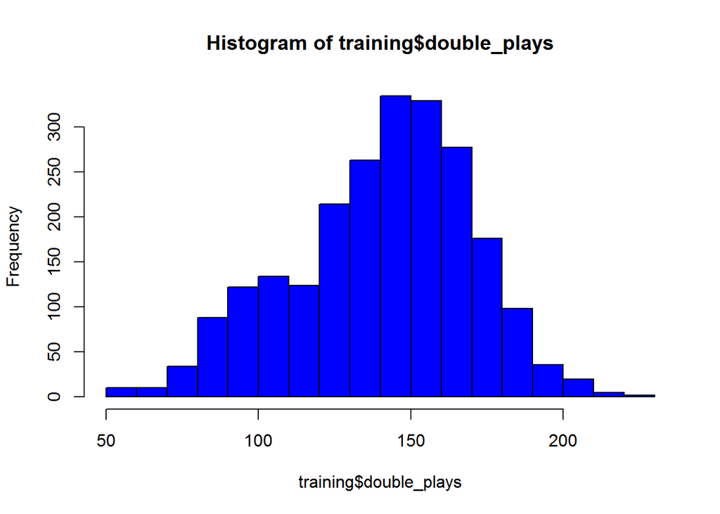

```r
hist(training$double_plays, col="blue")
```

- We can deduce from the above model that some of the variables are not comtributing meaningfully to the analysis, we therefore proceeded by using a statistical tool for selecting the best model for the analysis.
- We shall select the best model by using both forward and backward selection process

```r
stepwise <- step(fit1, direction = "both") # Model Selection using both FORWARD AND BACKWARD selection.
```

```
## Start:  AIC=11410.79
## wins ~ base_hits + singles + doubles + triples + homeruns + walks +
##     b_strikeouts + stolen_bases + hits_allowed + homeruns_allowed +
##     walks_allowed + p_strikeouts + errors + double_plays
##
##                    Df Sum of Sq    RSS   AIC
## - doubles           1         8 337913 11409
## - homeruns_allowed  1        12 337918 11409
## - singles           1        22 337927 11409
## - base_hits         1        30 337935 11409
## <none>                          337905 11411
## - walks_allowed     1       325 338230 11411
## - homeruns          1       364 338269 11411
## - hits_allowed      1       380 338285 11411
## - p_strikeouts      1       529 338434 11412
## - b_strikeouts      1       551 338456 11412
## - walks             1      1833 339738 11421
## - triples           1      4036 341941 11436
## - double_plays      1     23396 361301 11561
## - stolen_bases      1     31614 369519 11612
## - errors            1     67987 405892 11826
##
## Step:  AIC=11408.84
## wins ~ base_hits + singles + triples + homeruns + walks + b_strikeouts +
##     stolen_bases + hits_allowed + homeruns_allowed + walks_allowed +
##     p_strikeouts + errors + double_plays
##
##                    Df Sum of Sq    RSS   AIC
## - homeruns_allowed  1         9 337921 11407
## - base_hits         1       129 338041 11408
## <none>                          337913 11409
## - walks_allowed     1       323 338236 11409
## - hits_allowed      1       373 338286 11409
## - p_strikeouts      1       522 338435 11410
## - b_strikeouts      1       573 338486 11411
## + doubles           1         8 337905 11411
## - singles           1       707 338620 11412
## - homeruns          1      1140 339053 11414
## - walks             1      1923 339836 11420
## - triples           1     15400 353313 11508
```

[output cut: 32 more lines]

```
## <none>                          338047 11406
## - walks_allowed     1       374 338421 11406
## + base_hits         1       126 337921 11407
## + doubles           1       107 337940 11407
## - b_strikeouts      1       502 338549 11407
## + homeruns_allowed  1         6 338041 11408
## - p_strikeouts      1       675 338722 11408
## - hits_allowed      1       780 338827 11409
## - walks             1      2180 340227 11418
## - singles           1      3669 341716 11428
## - homeruns          1     17750 355797 11520
## - triples           1     23419 361466 11556
## - double_plays      1     23569 361616 11557
## - stolen_bases      1     31611 369658 11607
## - errors            1     84462 422509 11911
```

- The table below depicts the summary of the selected model:

```r
summary(stepwise)
```

```
##
## Call:
## lm(formula = wins ~ singles + triples + homeruns + walks + b_strikeouts +
##     stolen_bases + hits_allowed + walks_allowed + p_strikeouts +
##     errors + double_plays, data = training)
##
## Residuals:
##     Min      1Q  Median      3Q     Max
## -52.918  -7.853  -0.090   7.687  64.484
##
## Coefficients:
##                Estimate Std. Error t value Pr(>|t|)
## (Intercept)   67.316797   5.651283  11.912  < 2e-16 ***
## singles        0.025656   0.005175   4.957 7.68e-07 ***
## triples        0.191212   0.015268  12.524  < 2e-16 ***
## homeruns       0.098316   0.009017  10.903  < 2e-16 ***
## walks          0.035400   0.009264   3.821 0.000136 ***
## b_strikeouts  -0.010937   0.005967  -1.833 0.066955 .
## stolen_bases   0.077319   0.005314  14.550  < 2e-16 ***
## hits_allowed   0.007471   0.003269   2.286 0.022372 *
## walks_allowed -0.014035   0.008872  -1.582 0.113793
## p_strikeouts  -0.011133   0.005235  -2.127 0.033535 *
## errors        -0.139416   0.005862 -23.784  < 2e-16 ***
## double_plays  -0.156985   0.012495 -12.564  < 2e-16 ***
## ---
## Signif. codes:  0 '***' 0.001 '**' 0.01 '*' 0.05 '.' 0.1 ' ' 1
##
## Residual standard error: 12.22 on 2264 degrees of freedom
## Multiple R-squared:  0.4012, Adjusted R-squared:  0.3982
## F-statistic: 137.9 on 11 and 2264 DF,  p-value: < 2.2e-16
```

> The above selection process depicts the best model for the analysis.
- A look at the plots.

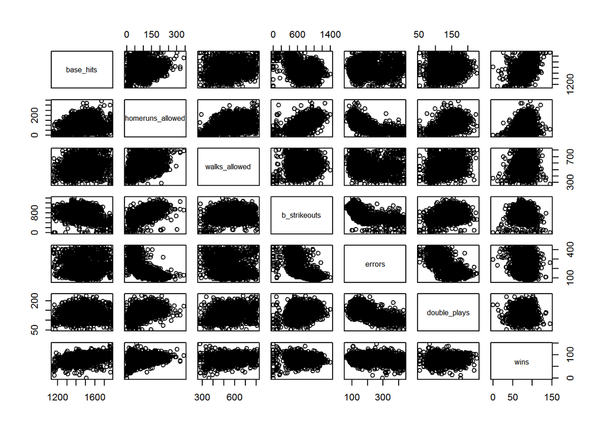

```r
#fit2 <- training[c("base_hits","homeruns","walks_allowed","p_strikeouts","errors", "double_plays", "wins", "hit_by_pitch")]
#c("TEAM_BATTING_H", "TEAM_PITCHING_HR" , "TEAM_PITCHING_BB", "TEAM_PITCHING_SO", "TEAM_FIELDING_E", "TEAM_FIELDING_DP", "TARGET_WINS", "TEAM_BATTING_HBP")]

fit2 <- training[, c("base_hits","homeruns_allowed","walks_allowed","b_strikeouts","errors", "double_plays", "wins")]

par(mfrow=c(2,2))
plot(fit2)
```

- **NOTE:** One of the variable (**base_hits**) is not contributing significantly to the analysis, we therefore remove the variable and see the effect on the other variables.

```r
fit3 <- lm(wins ~. -base_hits, data = fit2)


summary(fit3)
```

```
##
## Call:
## lm(formula = wins ~ . - base_hits, data = fit2)
##
## Residuals:
##     Min      1Q  Median      3Q     Max
## -73.679  -8.800   0.391   8.980  55.447
##
## Coefficients:
##                    Estimate Std. Error t value Pr(>|t|)
## (Intercept)      122.700790   3.500441  35.053  < 2e-16 ***
## homeruns_allowed   0.061464   0.007905   7.775 1.13e-14 ***
## walks_allowed      0.028101   0.003064   9.172  < 2e-16 ***
## b_strikeouts      -0.026850   0.001777 -15.112  < 2e-16 ***
## errors            -0.087219   0.005985 -14.572  < 2e-16 ***
## double_plays      -0.194720   0.013422 -14.508  < 2e-16 ***
## ---
## Signif. codes:  0 '***' 0.001 '**' 0.01 '*' 0.05 '.' 0.1 ' ' 1
##
## Residual standard error: 14.11 on 2270 degrees of freedom
## Multiple R-squared:  0.1995, Adjusted R-squared:  0.1977
## F-statistic: 113.1 on 5 and 2270 DF,  p-value: < 2.2e-16
```

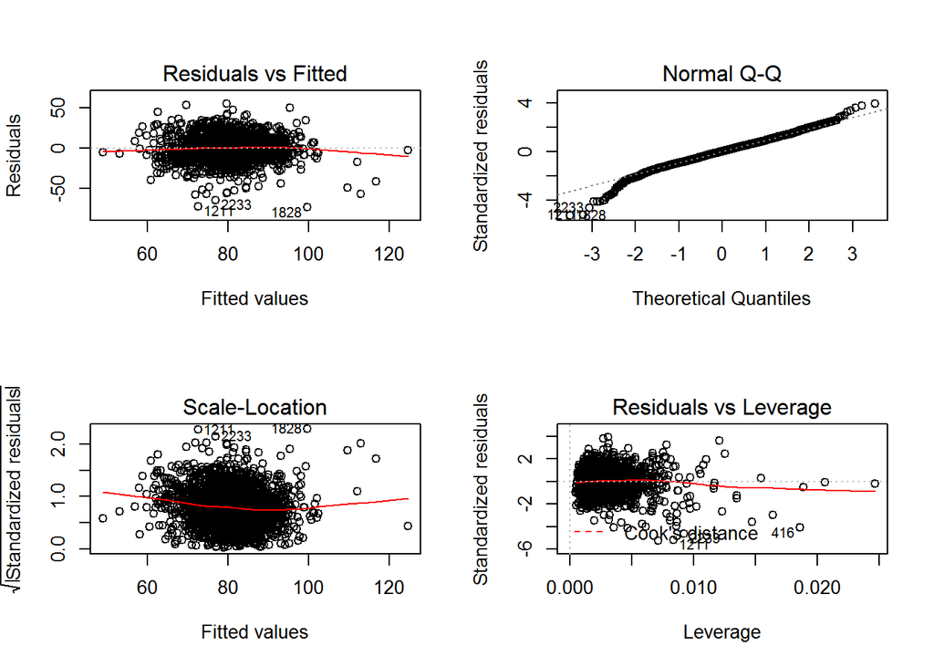

```r
par(mfrow=c(2,2))
plot(fit3)
```

$\hat { \quad y } =\quad \hat { { \beta }_{ 0 } } \quad +\quad \hat { { \beta }_{ 1 }{ x }_{ 1 } } \quad +\quad \hat { { \beta }_{ 2 }{ x }_{ 2 } } +....+\quad \hat { { \beta }_{ n }{ x }_{ n } } + \quad \hat {\quad e}$

where $\hat { \quad y }$ is the predicted value of y, and ${ \beta }_{ 0 },\quad { \beta }_{ 1 },\quad { \beta }_{ 2 }$

are the estimated co-effients.

> **INTERPRETATIONS**

> Analysis of Variance (ANOVA) is adopted here to show the effect and interaction between the variables.
- We shall also obtain there respective confident intervals.

```r
anova(fit3, test= "F")
```

```
## Analysis of Variance Table
##
## Response: wins
##                    Df Sum Sq Mean Sq F value    Pr(>F)
## homeruns_allowed    1  20167   20167 101.310 < 2.2e-16 ***
## walks_allowed       1  15586   15586  78.294 < 2.2e-16 ***
## b_strikeouts        1  21623   21623 108.624 < 2.2e-16 ***
## errors              1  13343   13343  67.028 4.411e-16 ***
## double_plays        1  41898   41898 210.475 < 2.2e-16 ***
## Residuals        2270 451879     199
## ---
## Signif. codes:  0 '***' 0.001 '**' 0.01 '*' 0.05 '.' 0.1 ' ' 1
```

```r
confint(fit3)
```

```
##                         2.5 %       97.5 %
## (Intercept)      115.83639270 129.56518824
## homeruns_allowed   0.04596174   0.07696530
## walks_allowed      0.02209289   0.03410962
## b_strikeouts      -0.03033417  -0.02336594
## errors            -0.09895586  -0.07548119
## double_plays      -0.22104057  -0.16840000
```